# 2025-09-12_2-1

## Вложенные условные инструкции

Внутри условных инструкций можно использовать любые инструкции языка Python, в том числе и условную инструкцию.

Получаем вложенное ветвление – после одной развилки в ходе исполнения программы появляется другая развилка.

При этом вложенные блоки имеют больший размер отступа (например, 8 пробелов).

Покажем это на примере программы, которая по данным ненулевым числам **x** и **y** определяет, в какой из четвертей координатной плоскости находится точка **(x,y)**:

```python
x = int(input())
```

```
1
```

```python
y = int(input())
```

```
-1
```

```python
if x > 0:
    if y > 0:             # x > 0, y > 0
        print('1-я')
    else:                 # x > 0, y <= 0
        print('4-я')
else:
    if y > 0:             # x <= 0, y > 0
        print('2-я')
    else:                # x <= 0, y <= 0
        print('3-я')
```

```
4-я
```

В этом примере использовали комментарии – текст, который интерпретатор игнорирует. Комментариями в Python является **символ #** и весь текст после этого символа до конца строки.

## Каскадные условные инструкции

Условное выражение может включать множество проверок. Общий синтаксис у него следующий:

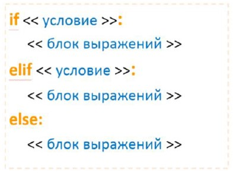

Блок выражений, относящийся к else, выполняется, когда все вышестоящие условия вернули False.

```python
pH = 3.0
if pH == 8:
    print(f'{pH} это pH воды')
elif 7.36 < pH < 7.44:
    print(f'{pH} это pH крови')
```

```python
pH = 3.0
if pH == 8:
    print(f'{pH} это pH воды')
elif 7.36 < x < 7.44:
    print(f'{pH} это pH крови')
else:
    print('Что это?!')
```

```
Что это?!
```

Пример программы, определяющий четверть координатной плоскости, можно переписать используя "каскадную" последовательность операцией **if… elif… else**:

```python
x = int(input())
```

```
1
```

```python
y = int(input())
```

```
2
```

```python
if x > 0 and y > 0:
    print('1-я')
elif x > 0  and y < 0:
    print('4-я')
elif x < 0 and y > 0:
    print('2-я')
else:
    print('3-я')
```

```
1-я
```

Существует так же **краткая форма записи**:

**X = A if условие else B**

Заменяет собой конструкцию вида:

if условие: x = A else: x = B

# Инструкция pass в Python

Оператор **pass** не делает ничего. Он может использоваться когда синтаксически требуется присутствие оператора, но от программы не требуется действий.

В реальной программе так лучше не делать, но при создании прототипа программы - вполне.

```python
x = 0
if x > 0:
    pass
else:
    print('---')
```

[output not shown]

**pass** также может применяться в качестве заглушки для тела функции или условия при создании нового кода, позволяя вам сохранить абстрактный взгляд на вещи. Но нужно помнить, что оператор **pass** игнорируется без каких-либо сигналов и в некоторых случаях может стать не лучшим выбором.

```python
if простое условие:
    pass
else:
    действия
```